# MovieClusters

Carlton Hencey

December 10, 2018

## One of the biggest businesses in America is the movie industry. Billions of dollars are spent every year in movie production. However, not all of these movies are able to make their money back. Some movies thrive, while others lose millions of dollars. In order to better determine what factors are associated with movies, several qualtitative variables were clustered with gross revenue of over 6800 movies over the past 32 years. This data was scraped from IMBD and contains information on the movie’s budget, runtime, IMDB score, number of IMDB votes, and how long ago the movie was released.

## The first step was to enter the data and include only the impactful variables moving forward. The code for the data cleaning process is included below.

```r
library(fpc)
library(dplyr)
Movies<-read.csv("movies.csv")
Movies$released<-as.Date(Movies$released, format="%m/%d/%Y")

MovieData<-Movies[,c(1,6,10,11,13,15)]
MovieData$age<-(2018-MovieData$year)
MovieData<-MovieData[,-6]
head(MovieData)
```

```
##     budget     gross runtime score  votes age
## 1  8000000  52287414      89   8.1 299174  32
## 2  6000000  70136369     103   7.8 264740  32
## 3 15000000 179800601     110   6.9 236909  32
## 4 18500000  85160248     137   8.4 540152  32
## 5  9000000  18564613      90   6.9  36636  32
## 6  6000000 138530565     120   8.1 317585  32
```

## The next step in the process is to understand how these clusters will work. First, all of the data was scaled so that the columns with larger values would not skew the clusters. Next, the Ward.D2 cluster was determined as the optimal clustering method, and 5 distinct clusters were determined based on the Cluster Dendrogram. The code and visuals for this process are shown below.

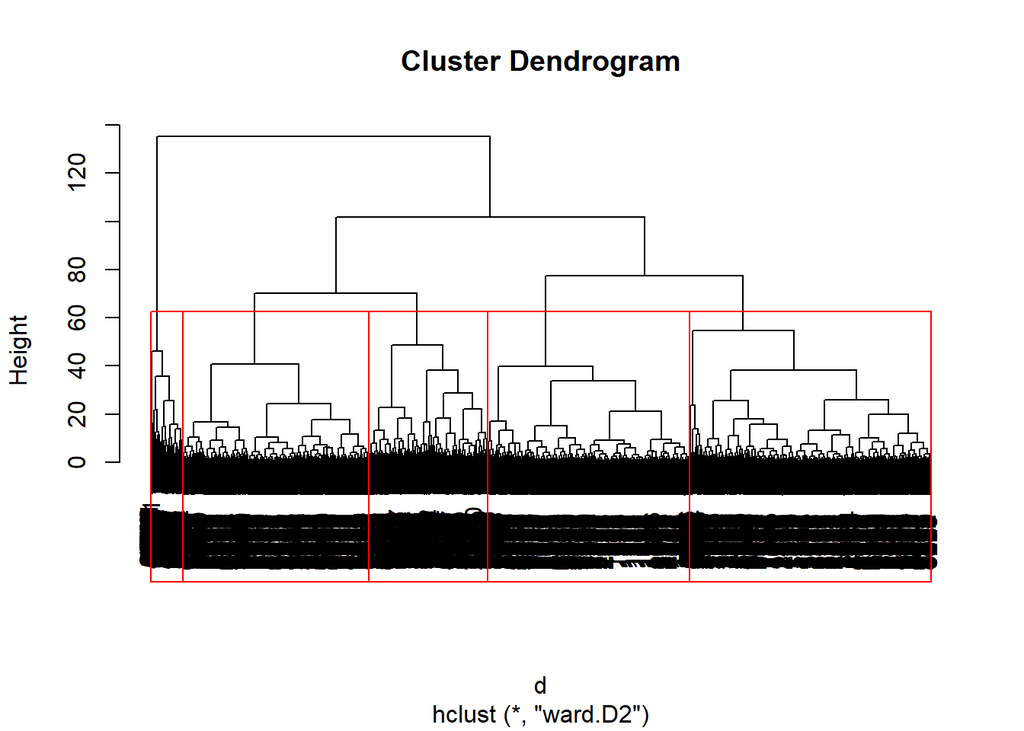

```r
ClusterData<-scale(MovieData[,c(1:6)])

d <- dist(ClusterData, method = "euclidean")
fit <- hclust(d, method="ward.D2")
plot(fit)
rect.hclust(fit, k=5, border="red")
```

## Lastly, the data was broken down into the five clusters, as stated above, and the average values for all of the variables for each one of these clusters were calculated and put into a data frame. The calculations for the clusters and the ending data frame is provided below.

```r
groups<-cutree(fit, k=5)

DataGroups<-as.data.frame(cbind(ClusterData,groups))
GroupMeans<- DataGroups %>%
  select(budget,runtime,score,votes,age,groups,gross) %>%
  group_by(groups) %>%
  summarize(budget=mean(budget),runtime=mean(runtime),score=mean(score),votes=mean(votes),
            age=mean(age),AvgGross=mean(gross))

as.data.frame(GroupMeans)
```

```
##   groups     budget      runtime      score       votes        age
## 1      1  0.9630844  0.212775981  0.2377467  0.81866964 -0.3840527
## 2      2 -0.3697459  0.272893355  0.4920399 -0.33231073  0.6083654
## 3      3 -0.3823389 -0.642749359 -1.0134362 -0.44171502  0.6354705
## 4      4  3.0552605  1.157523152  0.8196596  2.83640621 -0.7441019
## 5      5 -0.2440083  0.008713604  0.1682204 -0.09869582 -1.1039717
##     AvgGross
## 1  0.7522461
## 2 -0.3168621
## 3 -0.3594653
## 4  3.3847772
## 5 -0.2593668
```